# Regression Task: House Prices Prediction

- Show All Code
- Hide All Code
- View Source

Project

Solve a regression problem with deep neural networks (DNN): House Prices Prediction.

Author

Wu Hao

Published

2025/2/6

## Global Settings

We import all the packages here to make us easier to call.

```python
# Numerical Operations
import math
import numpy as np

# Reading/Writing Data
import pandas as pd
import os
import csv
import hashlib
import tarfile
import zipfile
import requests

# Pytorch
import torch
import torch.nn as nn
from torch.utils.data import Dataset, DataLoader, random_split

#d2l
from d2l import torch as d2l

# For plotting learning curve
from torch.utils.tensorboard import SummaryWriter
```

For the reproducibility of the experiment, we fix the random number generator seeds here.

```python
#Fixes random number generator seeds for reproducibility.
def same_seed(seed):
    torch.backends.cudnn.deterministic = True
    torch.backends.cudnn.benchmark = False
    np.random.seed(seed)
    torch.manual_seed(seed)
    if torch.cuda.is_available():
        torch.cuda.manual_seed_all(seed)
```

## Dataset

We can download data from [House Prices](https://www.kaggle.com/c/house-prices-advanced-regression-techniques)

We use the function defined in here to download and read the dataset.

```python
# name: the name of file/directory
def download(name, cache_dir=os.path.join('..', 'data')):
    assert name in DATA_HUB, f"{name} is not existed in {DATA_HUB}"
    url, sha1_hash = DATA_HUB[name]
    os.makedirs(cache_dir, exist_ok=True)
    fname = os.path.join(cache_dir, url.split('/')[-1])
    if os.path.exists(fname):
        sha1 = hashlib.sha1()
        with open(fname, 'rb') as f:
            while True:
                data = f.read(1048576)
                if not data:
                    break
                sha1.update(data)
        if sha1.hexdigest() == sha1_hash:
            return fname
    print(f'From {url} download {fname}...')
    r = requests.get(url, stream=True, verify=True)
    with open(fname, 'wb') as f:
        f.write(r.content)
    return fname

DATA_HUB = dict()
DATA_URL = 'http://d2l-data.s3-accelerate.amazonaws.com/'

DATA_HUB['kaggle_house_train'] = (
    DATA_URL + 'kaggle_house_pred_train.csv',
    '585e9cc93e70b39160e7921475f9bcd7d31219ce')

DATA_HUB['kaggle_house_test'] = (
    DATA_URL + 'kaggle_house_pred_test.csv',
    'fa19780a7b011d9b009e8bff8e99922a8ee2eb90')

train_data_pre = pd.read_csv(download('kaggle_house_train'))
test_data_pre = pd.read_csv(download('kaggle_house_test'))
```

Some basic information about the dataset:

```python
## Shape of Dataset
print("Shape of train_data is {}".format(train_data_pre.shape))
print("Shape of test_data is {}".format(test_data_pre.shape))

print(train_data_pre.iloc[0:4, [0, 1, 2, 3, -3, -2, -1]])
```

```
Shape of train_data is (1460, 81)
Shape of test_data is (1459, 80)
   Id  MSSubClass MSZoning  LotFrontage SaleType SaleCondition  SalePrice
0   1          60       RL         65.0       WD        Normal     208500
1   2          20       RL         80.0       WD        Normal     181500
2   3          60       RL         68.0       WD        Normal     223500
3   4          70       RL         60.0       WD       Abnorml     140000
```

Therefore, the shape of train_data is 1460×81 consisting of $id + 79 features + Sale_price$, and the shape of test_data is 1459×80 without the Sale_price.

## Training Code

### Training Configurations

```python
device = 'cuda' if torch.cuda.is_available() else 'cpu'
config = {
    'seed': 342425,       # seed number, we can pick lucky number. :)
    'valid_ratio': 0.2,   # validation_size = train_size * valid_ratio
    'n_epochs': 200,     # Number of epochs.
    'batch_size': 64,
    'learning_rate': 0.5,
    'early_stop': 40,    # If model has not improved for this many consecutive epochs, stop training.
    'save_path': './house-price-prediction/model.ckpt'  # our model will be saved here.
}
```

### Dataset Processing

First, we apply a heuristic, replacing all missing values by the corresponding feature’s mean.

Next, we deal with discrete values. These include features such as “MSZoning”. We replace them by a one-hot encoding in the same way that we earlier transformed multi-class labels into vectors (see in Softmax Regression).

For instance, “MSZoning” assumes the values “RL” and “RM”. Dropping the “MSZoning” feature, two new indicator features “MSZoning_RL” and “MSZoning_RM” are created with values being either 0 or 1. According to one-hot encoding, if the original value of “MSZoning” is “RL”, then “MSZoning_RL” is 1 and “MSZoning_RM” is 0.

```python
def preprocess(train_data, test_data):
    # Remove the ID and label columns
    label = 'SalePrice'
    all_features = pd.concat((train_data.iloc[:, 1:-1], test_data.iloc[:, 1:]))

    # Standardize numerical columns
    numeric_features = all_features.dtypes[all_features.dtypes != 'object'].index
    all_features[numeric_features] = all_features[numeric_features].apply(
    lambda x: (x - x.mean()) / (x.std()))
    # Replace NAN numerical features by 0
    all_features[numeric_features] = all_features[numeric_features].fillna(0)
    # Replace discrete features by one-hot encoding
    all_features = pd.get_dummies(all_features, dummy_na=True, dtype=int)
    print(f"Shape of all_features is {all_features.shape}")
    # Save preprocessed features
    n_train = train_data.shape[0]
    train_features = torch.tensor(all_features[:n_train].values, dtype=torch.float32)
    test_data = torch.tensor(all_features[n_train:].values, dtype=torch.float32)
    train_labels = torch.tensor(train_data.SalePrice.values.reshape(-1, 1), dtype=torch.float32)
    train_data = torch.cat([train_features, train_labels], dim=1)
    print("Shape of train_data is {}".format(train_data.shape))
    print("Shape of test_data is {}".format(test_data.shape))

    return train_data, test_data

train_data, test_data = preprocess(train_data_pre, test_data_pre)
```

```
Shape of all_features is (2919, 330)
Shape of train_data is torch.Size([1460, 331])
Shape of test_data is torch.Size([1459, 330])
```

#### One-Hot Encoding

Input:

Color Size 0 Red S 1 Blue M 2 Green L 3 Red M

Output:

Color_Blue Color_Green Color_Red Size_L Size_M Size_S 0 0 0 1 0 0 1 1 1 0 0 0 1 0 2 0 1 0 1 0 0 3 0 0 1 0 1 0

We know some basic information about Dataset above. But except for train_data and test_data, we should construct a valid_data.

```python
#Split provided training data into training set and validation set
def train_valid_split(data_set, valid_ratio, seed):
    valid_set_size = int(valid_ratio * len(data_set))
    train_set_size = len(data_set) - valid_set_size
    train_set, valid_set = random_split(data_set, [train_set_size, valid_set_size],
                                        generator=torch.Generator().manual_seed(seed))

    train_set = np.array([data.numpy() for data in train_set])
    valid_set = np.array([data.numpy() for data in valid_set])

    return train_set, valid_set


train_data, valid_data = train_valid_split(train_data, config['valid_ratio'], config['seed'] )

print("Shape of train_data is {}".format(train_data.shape))
print("Shape of valid_data is {}".format(valid_data.shape))
```

```
Shape of train_data is (1168, 331)
Shape of valid_data is (292, 331)
```

In the next step, we should extract the features that are useful for our training from the dataset.

```python
#Selects useful features to perform regression
def select_feat(train_data, valid_data, test_data):
    label_train, label_valid = train_data[:,-1], valid_data[:,-1]
    feature_train, feature_valid, feature_test = train_data[:,:-1], valid_data[:,:-1], test_data
    feat_idx = list(range(len(feature_train[0])))

    return feature_train[:,feat_idx], feature_valid[:,feat_idx], feature_test[:,feat_idx], label_train, label_valid

# Select features
feature_train, feature_valid, feature_test, label_train, label_valid = select_feat(train_data, valid_data, test_data)

print("Number of features is {}".format(len(feature_train[0])))
```

```
Number of features is 330
```

So, we’ve got three sets of data — train_data, valid_data, and test_data, and we’ve also got their features. Now, it’s time to construct our dataset.

```python
#x: Features.
#y: Targets, if none, do prediction.
class HousePriceDataset(Dataset):
    def __init__(self, x, y=None):
        if y is None:
            self.y = y
        else:
            self.y = torch.FloatTensor(y)
        self.x = torch.FloatTensor(x)

    def __getitem__(self, idx):
        if self.y is None:
            return self.x[idx]
        else:
            return self.x[idx], self.y[idx]
    def __len__(self):
        return len(self.x)

train_dataset, valid_dataset, test_dataset = HousePriceDataset(feature_train, label_train), \
                                            HousePriceDataset(feature_valid, label_valid), \
                                            HousePriceDataset(feature_test)

# Pytorch data loader loads pytorch dataset into batches.
train_loader = DataLoader(train_dataset, batch_size=config['batch_size'], shuffle=True, pin_memory=True)
valid_loader = DataLoader(valid_dataset, batch_size=config['batch_size'], shuffle=True, pin_memory=True)
test_loader = DataLoader(test_dataset, batch_size=config['batch_size'], shuffle=False, pin_memory=True)

for X,y in train_loader:
    print(f"Shape of X is {X.shape}\nShape of y is {y.shape}")
    break
```

```
Shape of X is torch.Size([64, 330])
Shape of y is torch.Size([64])
```

At this point, we’ve finished building the dataset. With train_loader, we can get bulk data during the training process and pass it to the model. It’s time to construct our model.

## Model

In Recognize Handwritten Digits by CNN, we adopt a network consisting of two convolutional layers and three fully connected layers. But in this task, we don’t need such a complex model that could cause overfitting.

```python
# Regression Model
class Regression(nn.Module):
    def __init__(self, input_dim):
        super(Regression, self).__init__()
        self.layers = nn.Sequential(
            nn.Linear(input_dim, 128),
            nn.ReLU(),
            nn.Linear(128, 32),
            nn.ReLU(),
            nn.Linear(32, 1)
        )

    def forward(self, x):
        out = self.layers(x)
        out = out.squeeze(1) # (B, 1) -> (B)
        return out
```

Our model consisting of three fully connected layers.

We use the logarithm of the price forecasts to measure the variance, rather than using the difference in forecasts directly, because we are concerned with relative quantities, not absolute quantities

```python
criterion = nn.MSELoss() # loss function.

def log_rmse(pred, labels):
    clipped_preds = torch.clamp(pred, 1, float('inf'))
    rmse = torch.sqrt(criterion(torch.log(clipped_preds),
                           torch.log(labels)))
    return rmse.item()
```

### Training Loop

We’ve got everything we need for training. Let’s get start our training process.

```python
def trainer(train_loader, valid_loader, model, config, device):
    optimizer = torch.optim.Adam(model.parameters(), lr=config['learning_rate'], weight_decay=0.1)

    writer = SummaryWriter() # Writer of tensorboard.

    n_epochs, best_loss, step, early_stop_count = config['n_epochs'], math.inf, 0, 0

    for epoch in range(n_epochs):
        model.train()
        loss_record = []

        for x, y in train_loader:
            optimizer.zero_grad()               # Set gradient to zero.
            x, y = x.to(device), y.to(device)   # Move our data to device.
            pred = model(x)
            loss = criterion(pred, y)
            loss.backward()                     # Compute gradient(back propagation).
            optimizer.step()                    # Update parameters.
            step += 1
            loss_record.append(log_rmse(pred, y))

        mean_train_loss = sum(loss_record)/len(loss_record)
        writer.add_scalar('Loss/train', mean_train_loss, step)

        model.eval() # Set our model to evaluation mode.
        loss_record = []
        for x, y in valid_loader:
            x, y = x.to(device), y.to(device)
            with torch.no_grad():
                pred = model(x)
                loss = criterion(pred, y)

            loss_record.append(log_rmse(pred, y))

        mean_valid_loss = sum(loss_record)/len(loss_record)
        print(f'Epoch [{epoch+1}/{n_epochs}]: Train loss: {mean_train_loss:.4f}, Valid loss: {mean_valid_loss:.4f}')
        writer.add_scalar('Loss/valid', mean_valid_loss, step)

        if mean_valid_loss < best_loss:
            best_loss = mean_valid_loss
            torch.save(model.state_dict(), config['save_path']) # Save our best model
            print('Saving model with loss {:.3f}...'.format(best_loss))
            early_stop_count = 0
        else:
            early_stop_count += 1

        if early_stop_count >= config['early_stop']:
            print('\nModel is not improving, so we halt the training session.')
            return
```

### Start Training

```python
model = Regression(input_dim=feature_train.shape[1]).to(device) # put our model and data on the same computation device.
trainer(train_loader, valid_loader, model, config, device)
```

```
Epoch [1/200]: Train loss: 1.4911, Valid loss: 0.2592
Saving model with loss 0.259...
Epoch [2/200]: Train loss: 0.2063, Valid loss: 0.1789
Saving model with loss 0.179...
Epoch [3/200]: Train loss: 0.1661, Valid loss: 0.1349
Saving model with loss 0.135...
Epoch [4/200]: Train loss: 0.1362, Valid loss: 0.1385
Epoch [5/200]: Train loss: 0.1229, Valid loss: 0.1269
Saving model with loss 0.127...
Epoch [6/200]: Train loss: 0.1304, Valid loss: 0.1365
Epoch [7/200]: Train loss: 0.1212, Valid loss: 0.1201
Saving model with loss 0.120...
Epoch [8/200]: Train loss: 0.1229, Valid loss: 0.1207
Epoch [9/200]: Train loss: 0.1130, Valid loss: 0.1132
Saving model with loss 0.113...
Epoch [10/200]: Train loss: 0.1122, Valid loss: 0.1303
Epoch [11/200]: Train loss: 0.1180, Valid loss: 0.1240
Epoch [12/200]: Train loss: 0.1174, Valid loss: 0.1083
Saving model with loss 0.108...
Epoch [13/200]: Train loss: 0.1086, Valid loss: 0.1166
Epoch [14/200]: Train loss: 0.0994, Valid loss: 0.1331
Epoch [15/200]: Train loss: 0.1066, Valid loss: 0.1195
Epoch [16/200]: Train loss: 0.0990, Valid loss: 0.1173
Epoch [17/200]: Train loss: 0.0926, Valid loss: 0.1114
Epoch [18/200]: Train loss: 0.1034, Valid loss: 0.1118
Epoch [19/200]: Train loss: 0.0921, Valid loss: 0.1122
Epoch [20/200]: Train loss: 0.0876, Valid loss: 0.1052
Saving model with loss 0.105...
Epoch [21/200]: Train loss: 0.0865, Valid loss: 0.1104
Epoch [22/200]: Train loss: 0.0914, Valid loss: 0.1124
Epoch [23/200]: Train loss: 0.0895, Valid loss: 0.1213
Epoch [24/200]: Train loss: 0.0900, Valid loss: 0.1132
Epoch [25/200]: Train loss: 0.0902, Valid loss: 0.1189
Epoch [26/200]: Train loss: 0.0846, Valid loss: 0.1076
Epoch [27/200]: Train loss: 0.0845, Valid loss: 0.1263
Epoch [28/200]: Train loss: 0.1137, Valid loss: 0.1161
Epoch [29/200]: Train loss: 0.1128, Valid loss: 0.3281
Epoch [30/200]: Train loss: 0.2556, Valid loss: 0.1751
Epoch [31/200]: Train loss: 0.2060, Valid loss: 0.1543
Epoch [32/200]: Train loss: 0.1155, Valid loss: 0.1795
```

[output cut: 15 more lines]

```
Epoch [48/200]: Train loss: 0.0691, Valid loss: 0.1284
Epoch [49/200]: Train loss: 0.0638, Valid loss: 0.1236
Epoch [50/200]: Train loss: 0.0670, Valid loss: 0.1183
Epoch [51/200]: Train loss: 0.0704, Valid loss: 0.1528
Epoch [52/200]: Train loss: 0.0793, Valid loss: 0.1177
Epoch [53/200]: Train loss: 0.0776, Valid loss: 0.1346
Epoch [54/200]: Train loss: 0.0736, Valid loss: 0.1258
Epoch [55/200]: Train loss: 0.0763, Valid loss: 0.1285
Epoch [56/200]: Train loss: 0.0692, Valid loss: 0.1317
Epoch [57/200]: Train loss: 0.0853, Valid loss: 0.1290
Epoch [58/200]: Train loss: 0.0792, Valid loss: 0.1338
Epoch [59/200]: Train loss: 0.0679, Valid loss: 0.1287
Epoch [60/200]: Train loss: 0.0694, Valid loss: 0.1267

Model is not improving, so we halt the training session.
```

We can visualize our training progress by Tensorboard.

```bash
tensorboard --logdir=./posts/Project/runs/
```

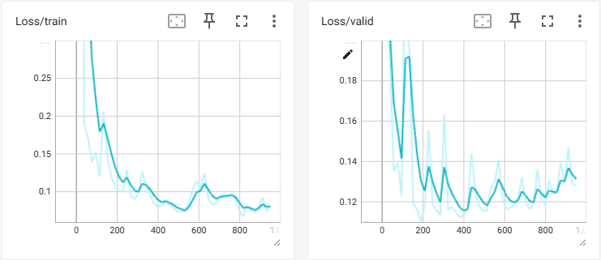

Loss

## Testing Code

We use the best model **model.ckpt** obtained through training to accomplish the prediction of house prices.

```python
# Prediction
def predict(test_loader, model, device):
    model.eval() # Set your model to evaluation mode.
    preds = []
    for x in test_loader:
        x = x.to(device)
        with torch.no_grad():
            pred = model(x)
            preds.append(pred.detach().cpu())
    preds = torch.cat(preds, dim=0).detach().numpy()
    return preds

model = Regression(input_dim=feature_train.shape[1]).to(device)
model.load_state_dict(torch.load(config['save_path'], weights_only=True))
preds = predict(test_loader, model, device)

test_data_pre = pd.read_csv(download('kaggle_house_test'))
test_data_pre['SalePrice'] = pd.Series(preds)

submission = pd.concat([test_data_pre['Id'], test_data_pre['SalePrice']], axis=1)
submission.to_csv('./house-price-prediction/submission.csv', index=False)
```

### Scores on Kaggle

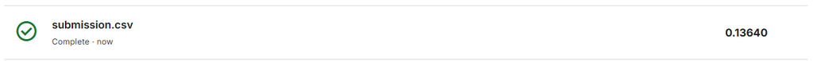

Results

Back to top